# Project 1: Wrangling, Exploration, Visualization

SDS322E

## Data Wrangling, Exploration, Visualization

### Brian Feng (btf457)

#### Introduction

I am interested in analyzing the similarities and differences between Fortune Top 500 companies to see if I can find any patterns. In this project, the numerical aspects focus on company finances and categorical aspects focus on variables such as: company locations, ceo gender, etc. The data used for this project is a dataset from Kaggle called “Fortune 1000”. It includes variables on top ranked Fortune companies, such as revenue, profit, whether the CEO is new.

```r
library(tidyverse)
fortune <- read_csv("~/project1/Fortune_1000.csv")
glimpse(fortune[-c(14, 18)])
```

```
## Rows: 1,000
## Columns: 16
## $ company             <chr> "Walmart", "Amazon", "Exxon Mobil", "Apple", "CVS…
## $ rank                <dbl> 1, 2, 3, 4, 5, 6, 7, 8, 9, 10, 11, 12, 13, 14, 15…
## $ rank_change         <dbl> 0, 3, -1, -1, 3, -2, -1, -1, 0, 0, 4, 0, 52, 0, -…
## $ revenue             <dbl> 523964.0, 280522.0, 264938.0, 260174.0, 256776.0,…
## $ profit              <dbl> 14881.0, 11588.0, 14340.0, 55256.0, 6634.0, 81417…
## $ `num. of employees` <dbl> 2200000, 798000, 74900, 137000, 290000, 391500, 3…
## $ sector              <chr> "Retailing", "Retailing", "Energy", "Technology",…
## $ city                <chr> "Bentonville", "Seattle", "Irving", "Cupertino", …
## $ state               <chr> "AR", "WA", "TX", "CA", "RI", "NE", "MN", "TX", "…
## $ newcomer            <chr> "no", "no", "no", "no", "no", "no", "no", "no", "…
## $ ceo_founder         <chr> "no", "yes", "no", "no", "no", "no", "no", "no", …
## $ ceo_woman           <chr> "no", "no", "no", "no", "yes", "no", "no", "no", …
## $ profitable          <chr> "yes", "yes", "yes", "yes", "yes", "yes", "yes", …
## $ CEO                 <chr> "C. Douglas McMillon", "Jeffrey P. Bezos", "Darre…
## $ Website             <chr> "https://www.stock.walmart.com", "https://www.ama…
## $ Ticker              <chr> "WMT", "AMZN", "XOM", "AAPL", "CVS", "BRKA", "UNH…
```

The code above provides a glimpse into the type of variables we will be looking at for this project.

#### Tidying: Reshaping

I will be performing tidying/reshaping later in the wrangling section.

#### Joining/Merging

The dataset that I chose doesn’t have a good pair of dataset that I can join it with so I intentionally split it up into a dataset that has all the numerical values and a dataset that has all the categorical values. The catch here is that I made the numerical dataset only 500 rows so that I will be joining datasets with different dimensions to make it more of a challenge.

```r
numerical <- fortune[c(1, 2, 3, 4, 5, 6)]
numerical <- numerical[1:500, ]
dim(numerical)
```

```
## [1] 500   6
```

```r
categorical <- fortune[-c(2, 3, 4, 5, 6, 14, 18)]
dim(categorical)
```

```
## [1] 1000   11
```

The numerical dataset has 500 rows and 6 variables while the categorical dataset has 1000 rows and 11 variables.

```r
# joining code
top500 <- inner_join(numerical, categorical, by = "company")
```

In my scenario, because my optimal result is the top 500 companies so I can either run an inner_join or a left_join with the numerical dataset on the leftside. After joining, the top 500 companies were kept while all companies from rank 501 - 1000 is omitted. Further, the numerical dataset has 6 variables while the categorical dataset has 11 variables, and since both dataset have the overlapping “company” ID, we will only be keeping one. Therefore, the resulting dataset, which we will be using throughout the project, called “top500” has a total of 500 rows and 16 variables.

#### Wrangling

The six core dplyr functions are used throughout the code below:

```r
library(dplyr)
library(knitr)

# To find the rank of the previous year, we will mutate and
# create a new variable by adding the variables of current
# 'rank' to 'rank_change'
top500 <- top500 %>% mutate(previous_rank = rank + rank_change)
top500 %>% select(rank, rank_change, previous_rank) %>% slice(1:5)
```

```
## # A tibble: 5 x 3
##    rank rank_change previous_rank
##   <dbl>       <dbl>         <dbl>
## 1     1           0             1
## 2     2           3             5
## 3     3          -1             2
## 4     4          -1             3
## 5     5           3             8
```

```r
# using regex with stringr to see how many company names end
# with the word 'Energy'
sum(str_detect(top500$company, "Energy$"))
```

```
## [1] 17
```

```r
# using summarize_all with at least 5 unique functions
top500 %>% select(is.numeric) %>% summarize_all(funs(sum, sd,
    min, max, n_distinct))
```

```
## # A tibble: 1 x 30
##   rank_sum rank_change_sum revenue_sum profit_sum `num. of employ…
##      <dbl>           <dbl>       <dbl>      <dbl>            <dbl>
## 1   125247             426   14210105.   1222684.         29192045
## # … with 25 more variables: previous_rank_sum <dbl>, rank_sd <dbl>,
## #   rank_change_sd <dbl>, revenue_sd <dbl>, profit_sd <dbl>, `num. of
## #   employees_sd` <dbl>, previous_rank_sd <dbl>, rank_min <dbl>,
## #   rank_change_min <dbl>, revenue_min <dbl>, profit_min <dbl>, `num. of
## #   employees_min` <dbl>, previous_rank_min <dbl>, rank_max <dbl>,
## #   rank_change_max <dbl>, revenue_max <dbl>, profit_max <dbl>, `num. of
## #   employees_max` <dbl>, previous_rank_max <dbl>, rank_n_distinct <int>,
## #   rank_change_n_distinct <int>, revenue_n_distinct <int>,
## #   profit_n_distinct <int>, `num. of employees_n_distinct` <int>,
## #   previous_rank_n_distinct <int>
```

```r
# another way to compute individual summary statistics for
# each variable
top500 %>% summarize_if(is.character, n_distinct)
```

```
## # A tibble: 1 x 11
##   company sector  city state newcomer ceo_founder ceo_woman profitable   CEO
##     <int>  <int> <int> <int>    <int>       <int>     <int>      <int> <int>
## 1     500     21   234    37        2           2         2          2   497
## # … with 2 more variables: Website <int>, Ticker <int>
```

```r
# See the distribution of top500 companies based on State
top500 %>% group_by(state) %>% summarize(count = n()) %>% arrange(desc(count))
```

```
## # A tibble: 37 x 2
##    state count
##    <chr> <int>
##  1 NY       54
##  2 CA       53
##  3 TX       50
##  4 IL       37
##  5 OH       27
##  6 PA       22
##  7 VA       22
##  8 FL       18
##  9 GA       18
## 10 MA       17
## # … with 27 more rows
```

```r
# See how profitable each sector is
sector_count <- top500 %>% group_by(sector) %>% summarize(profitability = mean(profitable ==
    "yes")) %>% arrange(desc(profitability))
sector_count
```

```
## # A tibble: 21 x 2
##    sector                        profitability
##    <chr>                                 <dbl>
##  1 Apparel                               1
##  2 Business Services                     1
##  3 Financials                            0.945
##  4 Industrials                           0.944
##  5 Transportation                        0.941
##  6 Technology                            0.932
##  7 Health Care                           0.925
##  8 Aerospace & Defense                   0.909
##  9 Household Products                    0.909
## 10 Hotels, Restaurants & Leisure         0.9
## # … with 11 more rows
```

```r
# See how many newcoming female CEO compare to experienced
# female CEO
top500 %>% filter(ceo_woman == "yes") %>% group_by(newcomer) %>%
    summarize(median_profit = median(profit))
```

```
## # A tibble: 2 x 2
##   newcomer median_profit
##   <chr>            <dbl>
## 1 no                861
## 2 yes               212.
```

```r
# writing own function to convert revenue to British Pound
pound_conversion <- function(x) {
    mean(x) * 0.73
}
top500 %>% group_by(ceo_founder) %>% summarize(pound_conversion(revenue))
```

```
## # A tibble: 2 x 2
##   ceo_founder `pound_conversion(revenue)`
##   <chr>                             <dbl>
## 1 no                               20373.
## 2 yes                              32834.
```

```r
# IMPORTANT: Tidying/Reshaping: utilized pivot_wider to
# reshape dataset.
sector_female_ceo <- top500 %>% group_by(sector, ceo_woman) %>%
    summarize(mean_profit = mean(profit)) %>% arrange(desc(sector))
sector_female_ceo %>% slice(1:5)
```

```
## # A tibble: 37 x 3
## # Groups:   sector [21]
##    sector                     ceo_woman mean_profit
##    <chr>                      <chr>           <dbl>
##  1 Aerospace & Defense        no              2019.
##  2 Aerospace & Defense        yes             2866
##  3 Apparel                    no              1189.
##  4 Apparel                    yes              643.
##  5 Business Services          no              2046.
##  6 Chemicals                  no               873.
##  7 Chemicals                  yes              852
##  8 Energy                     no              1416.
##  9 Energy                     yes             -974.
## 10 Engineering & Construction no               564.
## # … with 27 more rows
```

```r
sector_female_ceo <- sector_female_ceo %>% pivot_wider(names_from = "ceo_woman",
    names_prefix = "ceo_woman_", values_from = "mean_profit")
sector_female_ceo %>% slice(1:5)
```

```
## # A tibble: 21 x 3
## # Groups:   sector [21]
##    sector                     ceo_woman_no ceo_woman_yes
##    <chr>                             <dbl>         <dbl>
##  1 Aerospace & Defense               2019.         2866
##  2 Apparel                           1189.          643.
##  3 Business Services                 2046.           NA
##  4 Chemicals                          873.          852
##  5 Energy                            1416.         -974.
##  6 Engineering & Construction         564.           NA
##  7 Financials                        4133.         4463.
##  8 Food & Drug Stores                2194.         -422.
##  9 Food, Beverages & Tobacco         1732.          678.
## 10 Health Care                       3574.         4314.
## # … with 11 more rows
```

From the dimensions of before and after, we can see how we succesfully converted the dataset from 37 rows to 21 rows and made it visually more pleasing with tidying and reshaping techniques.

#### Visualizing

```r
male_vs_female <- top500 %>% group_by(ceo_woman) %>% select(revenue,
    profit, `num. of employees`) %>% gather(name, value, -c(ceo_woman))
male_vs_female %>% head
```

```
## # A tibble: 6 x 3
## # Groups:   ceo_woman [2]
##   ceo_woman name     value
##   <chr>     <chr>    <dbl>
## 1 no        revenue 523964
## 2 no        revenue 280522
## 3 no        revenue 264938
## 4 no        revenue 260174
## 5 yes       revenue 256776
## 6 no        revenue 254616
```

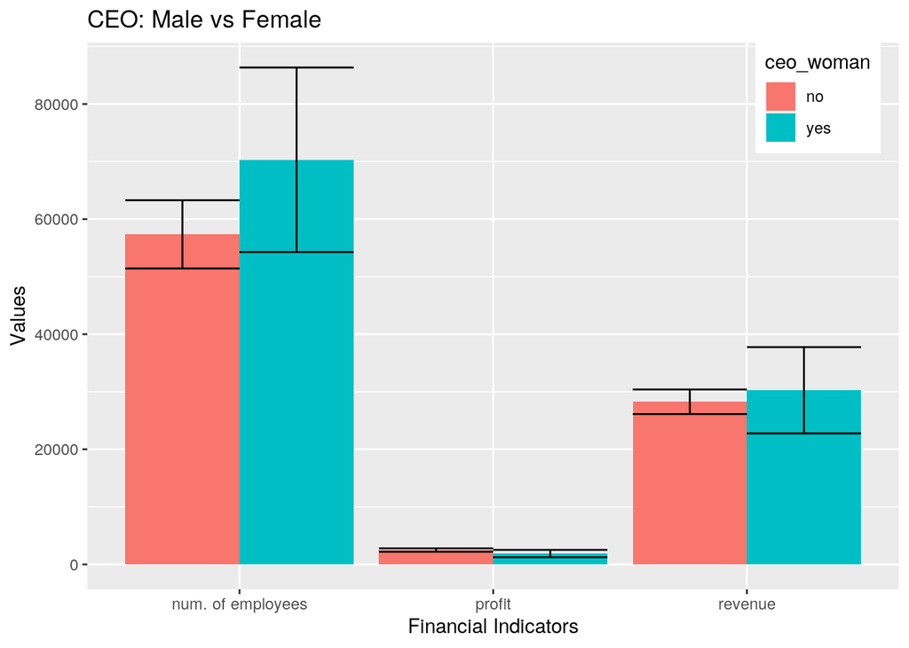

```r
male_vs_female %>% ggplot(aes(x = name, y = value, fill = ceo_woman)) +
    geom_bar(stat = "summary", position = "dodge") + geom_errorbar(stat = "summary",
    position = "dodge") + ggtitle("CEO: Male vs Female") + xlab("Financial Indicators") +
    ylab("Values") + theme(legend.position = c(0.9, 0.9)) + scale_y_continuous(breaks = seq(0,
    1e+05, 20000))
```

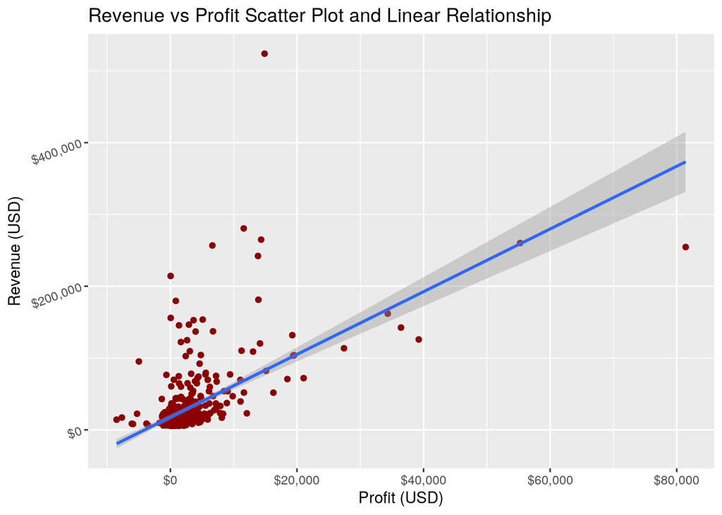

```r
top500 %>% ggplot(aes(x = profit, y = revenue)) + geom_point(color = "dark red") +
    geom_smooth(method = "lm") + scale_x_continuous(labels = scales::dollar) +
    scale_y_continuous(labels = scales::dollar) + ggtitle("Revenue vs Profit Scatter Plot and Linear Relationship") +
    xlab("Profit (USD)") + ylab("Revenue (USD)") + theme(axis.text.y = element_text(angle = 20,
    hjust = 1))
```

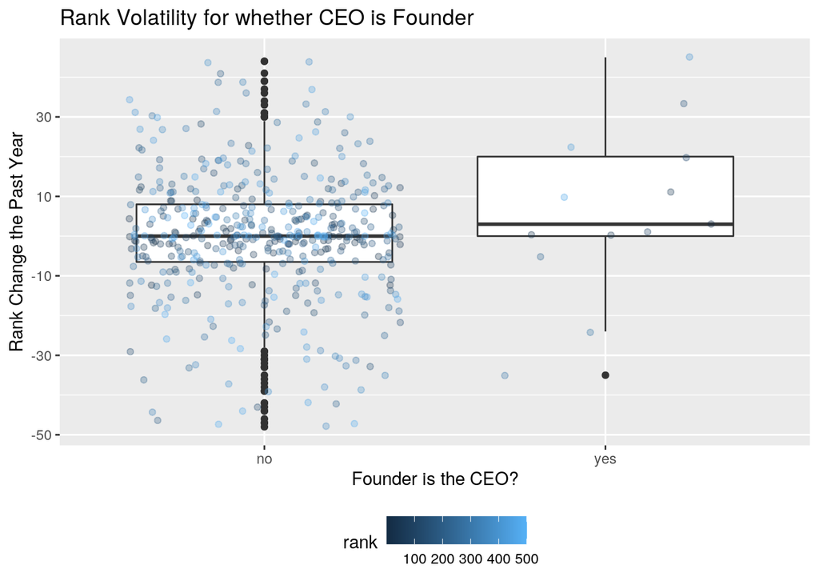

```r
top500 %>% filter(abs(rank_change) < 50) %>% ggplot(aes(y = rank_change,
    x = ceo_founder)) + geom_boxplot() + geom_jitter(alpha = 0.3,
    aes(color = rank)) + theme(legend.position = "bottom") +
    scale_y_continuous(breaks = seq(-50, 50, 20)) + ggtitle("Rank Volatility for whether CEO is Founder ") +
    xlab("Founder is the CEO?") + ylab("Rank Change the Past Year")
```

This boxplot compares whether having the founder of the company as the CEO affects how volatile the company is by using the rank change in the past year as the indicator. Companies with the CEO not being the founder has a mean closer to the 0 rank_change mark, while companies with founder as CEO has a higher rank change mean, which indicates that it is rising in ranks (a good thing). However, we do have to note that comapnies with founders as CEO has a significantly smaller sample size so it might not be best to draw conclusions direcly from here, and further analyses/tests is needed.

#### Concluding Remarks

This was a very informative and hands-on project. I had a lot of fun doing it!